# **[Universidade Federal Rural de Pernambuco](http://ufrpe.br/)** **[Departamento de Matemática](http://www.dm.ufrpe.br/)** **[Disciplina: Análise Combinatória](https://sites.google.com/site/ricardonunesmachadojr/disciplinas/analise-combinatoria)** **[Prof. Ricardo Machado](https://sites.google.com/site/ricardonunesmachadojr/)**

## [Índice de Aulas](https://sagectu.com.br/calculo1.github.io/combinatoria.html) Aula 12

## 1 - Probabilidades Condicionais 2 - Eventos Independentes 3 - Distribuição Binomial 4 - Exercícios 5 - Atividade

# Referências:

### Observação: Nota de aula produzida usando o software [SageMath](http://www.sagemath.org/), usando o notebook [Jupyter](https://jupyter.org/). Use o SageMathCell com vários exemplos em: sagectu.com.br/sagecell.html Referência bibliográfica sobre o SageMath: [1] Silva, L., Santos M., Machado, R., [*Elementos de Computação Matemática com SageMath*](https://sagectu.com.br/), SBM, 2019.

[figure not shown]

```python
load ('/home/ricardo/sage-9.0-Debian_GNU_Linux_9-x86_64/SageMath/Sage_Sync/Combinatoria/codigos.sage')
```

## 1 - Probabilidades Condicionais

### Solução Seja $B$ o evento $\{2, 4, 6\}$, foi dado que ocorreu $A=\{4, 5, 6\}$, então temos $A\cap B = \{ 4, 6\}$ e $$ P(A) = \frac{3}{6} = \frac{1}{2} ~~\text{ e }~~ P(A\cap B) = \frac{2}{6} = \frac{1}{3}. $$ Pela definição de probabilidade condicional, temos $$P(B|A) = \frac{P(A\cap B)}{P(A)} = \frac{\frac{1}{3}}{\frac{1}{2}} = \frac{2}{3}.$$ $\blacksquare$

### Teorema 1 Seja $A$ tal que $P(A)>0$. Então a probabilidade condicional é outra probabilidade sobre o espaço amostral $\Omega$, ou seja, valem as seguintes propriedades: \begin{equation} \begin{split} a) &~~ 0\leq P(B|A)\leq 1;\\ b) &~~ P(\emptyset|A) = 0,~ P(\Omega|A)=1;\\ c) &~~ \text{Se } B\cap C = \emptyset \text{ então } P((B\cup C)|A) = P(B|A) + P(C|A). \\ \end{split} \end{equation}

### Demonstração a) Como $0\leq P(A\cap B)\leq P(A)$ temos $$ 0\leq \frac{P(A\cap B)}{P(A)}\leq 1, ~~ \text{ ou seja }~~ 0\leq P(B|A)\leq 1. $$ b) $$ P(\emptyset|A) = \frac{P(\emptyset\cap A)}{P(A)} = \frac{P(\emptyset)}{P(A)} = \frac{0}{P(A)} = 0 $$ e $$ P(\Omega|A) = \frac{P(\Omega\cap A)}{P(A)} = \frac{P(A)}{P(A)} = 1. $$ c) \begin{equation} \begin{split} P((B\cup C)|A) = &~ \frac{P((B\cup C)\cap A)}{P(A)}\\ = &~ \frac{P((B\cap A)\cup (C\cap A))}{P(A)}\\ = &~ \frac{P(B\cap A)}{P(A)} + \frac{P(C\cap A)}{P(A)}\\ = &~ P(B|A) + P(C|A).\\ \end{split} \end{equation} $\blacksquare$

### Exemplo 3 Em um experimento aleatório é retirado sucessivamente e sem reposição três bolas de uma caixa que comtém 8 bolas pretas e 6 bolas brancas. Qual a probabilidade de que sejam três bolas brancas?

### Solução Considere os eventos: \begin{equation} \begin{split} A_1&:& \text{ a primeira bola é branca;}\\ A_2&:& \text{ a segunda bola é branca;}\\ A_3&:& \text{ a terceira bola é branca;}\\ \end{split} \end{equation} Queremos calcular a probabilidade $P(A_1\cap A_2\cap A_3)$.

[figure not shown]

```python
arvore_p([('x','A1','6/14'), ('A1','A2|A1','5/13'), ('A2|A1','n(A3|A1eA2)','4/12'), ('A2|A1','A3|(A1 e A2)','8/12'), ('A1','n(A2|A1)','8/13'), ('x','nA1','8/14')], 5000)
```

### A probabilidade de que a primeira bola seja branca é $\frac{6}{14}$. Dado que aconteceu $A_1$, a probabilidade de que a segunda bola seja branca é $\frac{5}{13}$. Dado que aconteceram $A_1$ e $A_2$, a probabilidade de que a terceira bola seja branca é $\frac{4}{12}$. Portanto $$ P(A_1\cap A_2\cap A_3) = \frac{6}{14}\cdot\frac{5}{13}\cdot\frac{4}{12} = \frac{5}{91} \approx 0.0549 \approx 5,5\% $$ Na solução deste problema, usamos a Proposição 1 (Regra do Produto de Probabilidades) $\blacksquare$

```python
((6/14)*(5/13)*(4/12)).n()
```

```
0.0549450549450549
```

### Proposição 1 (Regra do Produto de Probabilidades) Sejam $A_1, A_2, \cdots, A_n$ eventos de um espaço amostral $\Omega$ e $P$ uma probabilidade em $\Omega$. Se $$ P(A_1\cap A_2\cap \cdots \cap A_n) \neq 0, $$ então \begin{equation} \begin{split} P(A_1\cap A_2\cap \cdots \cap A_n) = &~ P(A_1)\cdot P(A_2|A_1)\cdot P(A_3|(A_1\cap A_2))\cdots\\ &~ \cdots P(A_n|(A_1\cap A_2\cap \cdots \cap A_{n-1})). \\ \end{split} \end{equation}

### Demonstração Para dois conjuntos a fórmula é verdadeira, pois coincide com a definição de probabilidade condicional. Vamos usar o Princípio de Indução Completa para mostrar que o resultado é verdadeiro. Suponha o resultado válido para $n-1$ eventos. Então \begin{equation} \begin{split} \overbrace{P(A_1\cap A_2\cap \cdots \cap A_{n-1})}^{(\blacklozenge)} = &~ P(A_1)\cdot P(A_2|A_1)\cdot P(A_3|(A_1\cap A_2))\cdots\\ &~ \cdots P(A_{n-1}|(A_1\cap A_2\cap \cdots \cap A_{n-2})). \\ \end{split} \end{equation} é verdadeiro. Denote $A_1\cap A_2\cap \cdots \cap A_{n-1}$ por $B$, ou seja $B = A_1\cap A_2\cap \cdots \cap A_{n-1}$. Queremos a probabilidade $P(B\cap A_n)$ e vamos usar que o resultado é válido para $B\cap A_n$ e para $n-1$ eventos. Logo \begin{equation} \begin{split} P(B\cap A_n) = &~ P(B)\cdot P(A_n|B)\\ = &~ \underbrace{P(A_1\cap A_2\cap \cdots \cap A_{n-1})}_{(\blacklozenge)}\cdot P(A_n|B) \\ \end{split} \end{equation} Substituindo $(\blacklozenge)$ e $B$ chegamos no resultado: \begin{equation} \begin{split} P(A_1\cap A_2\cap \cdots \cap A_n) = &~ P(A_1)\cdot P(A_2|A_1)\cdot P(A_3|(A_1\cap A_2))\cdots\\ &~ \cdots P(A_n|(A_1\cap A_2\cap \cdots \cap A_{n-1})). \\ \end{split} \end{equation} $\blacksquare$

### Exemplo 4 Sabe-se que $80\%$ das importações, por pessoas físicas, para o Brasil vem da China. A probabilidade de uma importação chegar na residência do comprador é de $30\%$ se for uma compra da China e $90\%$ caso contrário. Se uma importação for feita agora. a) Qual a probabilidade de que a compra ser da China e de chegar na residência do comprador? b) Qual a probabilidade de que a compra chegue na residência do comprador? c) Uma importação foi feita e o produto se perdeu. Qual a probabilidade de ter sido da china?

### Solução a) Usaremos as notações \begin{equation} \begin{split} C&:& \text{ é uma importação da China;}\\ R&:& \text{ o comprador Recebe a importação;}\\ \end{split} \end{equation} %$C = \{ c~|~c\text{ é uma importação da china} \}$ e %$R = \{ c~|~c \text{ é uma importação que chega na casa do comprador} \}$. \begin{equation} \begin{split} P(C\cap R) = &~ P(C) P(R|C)\\ = &~ 0,8\times 0,3 = 0,24 = 24\%. \\ \end{split} \end{equation}

### Solução b) (Qual a probabilidade de que a compra chegue na residência do comprador?) Para uma importação chegar na residência do comprador, ela pode ter sido feita da china ou do complementar da china. Usaremos $nR$ para dizer que não chegou na residência e $nC$ para dizer que não é da china. A probabilidade de que a importação chegue é dada por $$ P(R) = \underbrace{P( (C\cap R) \cup (nC\cap R))}_{(\bigstar)} = P(C\cap R) + P(nC\cap R). $$ Usando a Observação 1, temos \begin{equation} \begin{split} P(R) = &~ \overbrace{P(C)P(R|C) +P(nC)P(R|nC)}^{(\bigstar)} \\ = &~ 0,8\times 0,3 + 0,2\times 0.9 = 42\% \\ \end{split} \end{equation} Nesta solução, usamos o Teorema da Probabilidade Total (Teorema 2).

### Outra solução b) Para organizar melhor as ideias, desenhamos uma árvore com todas as possibilidades.

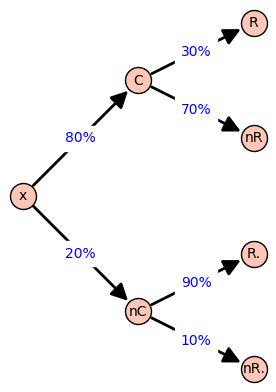

```python
arvore_p([('x','C','80%'), ('C','R','30%'), ('C','nR','70%'),('x', 'nC','20%'), ('nC', 'R.','90%'), ('nC', 'nR.','10%')], 350)
```

### Observa-se mais facilmente que a probabilidade da importação chegar na residência é dada por $$ 0,2\times0,9 + 0,8\times 0,3 = 0,42 = 42\% $$

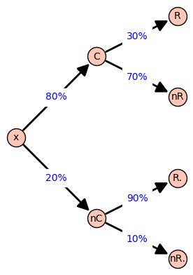

```python
arvore_p([('x','C','80%'), ('C','R','30%'), ('C','nR','70%'),('x', 'nC','20%'), ('nC', 'R.','90%'), ('nC', 'nR.','10%')], 350)
```

### Teorema 2 (Lei da Probabilidade Total) Sejam $A_1, A_2, \ldots, A_n$ e $B$ é um eventos tais que $$B\subset A_1\cup A_2\cup\cdots \cup A_n, ~~~~ A_i\cap A_j = \emptyset, ~~\text{ para } i\neq j. $$ e $$ P(A_i)>0,~~ i = 1, \ldots, n. $$ então $$ P(B) = P(A_1)P(B|A_1) + P(A_2)P(B|A_2)+\cdots + P(A_n)P(B|A_n). $$

### Demonstração Como vale $$B\subset A_1\cup A_2\cup\cdots \cup A_n, ~~~~ A_i\cap A_j = \emptyset, ~~\text{ para } i\neq j. $$ Temos $$ B = (A_1\cap B) \cup (A_2\cap B) \cup \cdots \cup (A_n\cap B) $$ com a união disjunta, portanto \begin{equation} \begin{split} P(B) = &~ P(A_1\cap B) + P(A_2\cap B) + \cdots + P(A_n\cap B)\\ = &~ P(A_1)P(B|A_1)+ P(A_2)P(B|A_2)+\cdots + P(A_n)P(B|A_n) \\ \end{split} \end{equation} $\blacksquare$

### Teorema 3 (Teorema de Bayes) Sejam $A_1, A_2, \ldots, A_n$ e $B$ é um eventos tais que $$B\subset A_1\cup A_2\cup\cdots \cup A_n, ~~~~ A_i\cap A_j = \emptyset, ~~\text{ para } i\neq j. $$ e $$ P(A_i)>0,~~ i = 1, \ldots, n. $$ então $$ P(A_i|B) = \frac{P(A_i)P(B|A_i)}{P(A_1)P(B|A_1)+\cdots +P(A_n)P(B|A_n)}. $$

### Demonstração Aplicando a definição de probabilidade condicional, temos \begin{equation} \begin{split} P(A_i|B) =&~ \frac{P(B\cap A_i)}{P(B)} \\ = &~ \frac{P(A_i)P(B|A_i)}{P(B)}. \\ \end{split} \end{equation} Usando o Teorema 2 e substituindo em $P(B)$, obtemos $$ P(A_i|B) = \frac{P(A_i)P(B|A_i)}{P(A_1)P(B|A_1)+ P(A_2)P(B|A_2)+\cdots + P(A_n)P(B|A_n)}.$$ $\blacksquare$

## 2 - Eventos Independentes

### Definição 2 Dois eventos $A$ e $B$ são chamados *independentes* se $$ P(A\cap B) = P(A)\cdot P(B). $$

### Definição 3 Sejam $A_1, A_2, \ldots, A_n$ eventos. $A_1, A_2, \ldots, A_n$ são *independentes* se, para todo $k$, e para todo $i_1, i_2, \ldots, i_k$, tem-se $$ P(A_{i_1}\cap A_{i_2}\cap \cdots \cap A_{i_k}) = P(A_{i_1})\cdot P(A_{i_2})\cdots P(A_{i_k}). $$

### Exemplo 5 Em um experimento aleatório é retirado sucessivamente, com reposição, três bolas de uma caixa que comtém 8 bolas pretas e 6 bolas brancas. Qual a probabilidade de que sejam três bolas brancas?

### Solução Considere os eventos: \begin{equation} \begin{split} A_1&:& \text{ a primeira bola é branca;}\\ A_2&:& \text{ a segunda bola é branca;}\\ A_3&:& \text{ a terceira bola é branca;}\\ \end{split} \end{equation} Observe que os eventos são independentes, portanto a probabilidade é \begin{equation} \begin{split} P(A_1\cap A_2\cap A_3) =& ~ P(A_1)\cdot P(A_2)\cdot P(A_3)\\ =& ~ \frac{6}{14}\cdot \frac{6}{14}\cdot \frac{6}{14}\\ =& ~\frac{27}{343} \\ =& ~ 0.07871 \\ \approx &~ 7,9\%. \end{split} \end{equation} $\blacksquare$

```python
((6/14)^3).n()
```

```
0.0787172011661808
```

## 3 - Distribuição Binomial

```python
(C(15, 7)*(1/2)^15).n()
```

```
0.196380615234375
```

### Teorema 4 (Teorema Binomial) Considere um experimento com apenas dois resultados possíveis, chamados de *sucesso* e *fracasso*. Denotaremos por $p$ a probabilidade de sucesso e por $q=1-p$ a probabilidade de fracasso. A probabilidade de ocorrerem exatamente $k$ sucessos em uma sequeência de $n$ provas independentes, na qual a probabilidade de sucesso em cada etapa é $p$, é igual a $$ C_n^k p^k(1-p)^{n-k}. $$

### Demonstração A probabilidade de nessas $n$ provas obtermos $k$ sucessos e, consequentemente $n-k$ fracassos em uma ordem fixada é $$ \underbrace{p\cdot p \cdots p}_{k\text{ fatores}}\underbrace{\cdot (1-p)\cdots(1-p)}_{(n-k)\text{ fatores}} = p^k(1-p)^{n-k}, $$ pois as provas são independentes. É claro que em outra ordem, a probabilidade seria a mesma, pois apenas a ordem dos fatores se altera. E o número de formas de arterar esta ordem é $C_n^k$. Assim a probabilidade de ortermos $k$ sucessos, em $n$ provas é $$ C_n^k p^k(1-p)^{n-k}. $$ $\blacksquare$

### 4 - Exercícios Um dado foi jogado três vezes. Calcule a probabilidade condicional de obter $5$ na primeira jogada, sabendo que a soma dos resultados foi $10$. $$ $$ Um estudante resolve um teste de múltipla escolha de $10$ questões, com $5$ alternativas por questão. Ele sabe $60\%$ da matéria do teste. Quando ele sabe uma questão, ele acerta, e, quando não sabe, escolhe a resposta ao acaso. Se ele acerta uma questão, qual é a probabilidade de que tenha sido por acaso? $$ $$ (ProfMat - qualificação 2012) Em uma caixa há três dados aparentemente idênticos. Entretanto, apenas dois s deles são normais, enquanto o terceiro tem três faces 1 e três faces 6. Um dado é retirado ao acaso e lençado duas vezes. Se a soma dos resultados obtidos for igual a 7, qual é a probabilidade condicional de que o dado sorteado tenha sido um dos dados normais? $$ $$ Em um torneio de ping-pong, um jogador $J_1$ deve enfrentar outros dois jogadores $J_2$ e $J_3$. Os resultados dos jogos são independentes e as probabilidades de $J_1$ ganhar de $J_2$ e de $J_3$ são $1/3$ e $2/3$ respectivamente. O jogador vencerá o terneiro se ganhar dois jogos consecutivos, de uma série de 3. Que série é mais favorável para o jogador: $$J_2J_3J_2 ~~\text{ ou }~~ J_3J_2J_3?$$ $$ $$ Sacam-se, com reposição, 6 bolas de uma urna que contém 9 bolas brancas e 5 bolas pretas. $$ $$ a) Qual a probabilidade de serem sacadas 3 bolas de cada cor? b) Qual seria a resposta no caso sem reposição? $$ $$

### 5 - Atividade $$ $$ $$ $$ $$ $$ $$ $$ $$ $$